# Patterns of Bay Wheels Dataset in 2019 vs 2020

## by Deepshikha Patni

## Investigation Overview

In this part of the project, I demonstrate the patterns I found in data analysis section. The main patterns are,

- Proportion of rides by different starting stations for 2019 and 2020.
- Proportion of rides by different user types in 2019 and 2020.
- Distribution of rides by distance in 2019 and 2020.
- Peak hours of rides in 2019 and 2020.
- Distribution of rides by days of week for each user type in 2019 and 2020.
- Comparsion of User Type by days of week and duration in 2019 and 2020.
- Comparsion of User Type by days of week and distance in 2019 and 2020.

## Dataset Overview

In this analysis, dataset used consist of monthly individual trip data from April 2019 to June 2019 and April 2020 to June 2020 in '.csv' format covering San Francisco Bay Area. In the datasets, there are 15 columns with 613046 rows values for data of year 2019 while there are 14 columns with 380678 rows values for data of year 2020 referring to observations.

## Proportion of bay wheel rides by different starting stations for 2019 and 2020

Though San Francisco Caltrain Station 2 was the busiest starting station with a ride count ~13700 in 2019 but in 2020, it was not among the busiest station. Also Market St at 10th St station, from where ~11500 rides were originated back in 2019, saw only ~1000 rides getting originated in 2020.

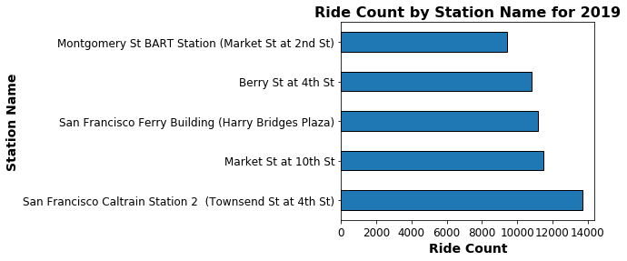

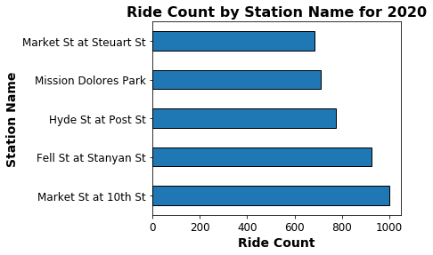

```python
#year 2019
plt.figure(figsize=(5,4))
df_19['start_station_name'].value_counts().head().plot.barh()
plt.xlabel('Ride Count', fontsize=14, weight='bold')
plt.ylabel('Station Name', fontsize=14, weight='bold')
plt.xticks(fontsize=12)
plt.yticks(fontsize=12)
plt.title('Ride Count by Station Name for 2019', fontsize=16, weight='bold');


#year 2020
plt.figure(figsize = (5,4))
df_20['start_station_name'].value_counts().head().plot.barh()
plt.xlabel('Ride Count', fontsize=14, weight='bold')
plt.ylabel('Station Name', fontsize=14, weight='bold')
plt.xticks(fontsize=12)
plt.yticks(fontsize=12)
plt.title('Ride Count by Station Name for 2020', fontsize=16, weight='bold');
```

## Proportion of Bay Wheels rides by different user types in 2019 and 2020

We can clearly see that in 2019 there were more **Subscriber** (**Member**) with count more than 510k which has reduced a lot in 2020 to ~33k. Similar trend could be observed in **Customer** count too i.e. in 2019 **Customer** (**Casual**) count was ~100k which dropped to ~38k in 2020.

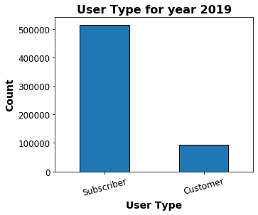

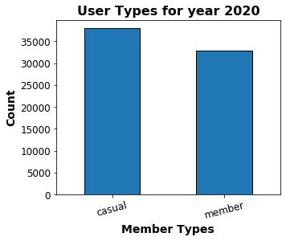

```python
# year 2019
plt.figure(figsize = (5,4))
df_19['user_type'].value_counts().plot.bar()
plt.xlabel('User Type', fontsize=14, weight='bold')
plt.ylabel('Count', fontsize=14, weight='bold')
plt.xticks(fontsize=12, rotation = 15)
plt.yticks(fontsize=12)
plt.title('User Type for year 2019', fontsize=16, weight='bold');

# year 2020
plt.figure(figsize = (5,4))
df_20['member_casual'].value_counts().plot.bar()
plt.xlabel('Member Types', fontsize=14, weight='bold')
plt.ylabel('Count', fontsize=14, weight='bold')
plt.xticks(fontsize=12, rotation = 15)
plt.yticks(fontsize=12)
plt.title('User Types for year 2020', fontsize=16, weight='bold');
```

## Distribution of Rides by Distance travelled in 2019 and 2020

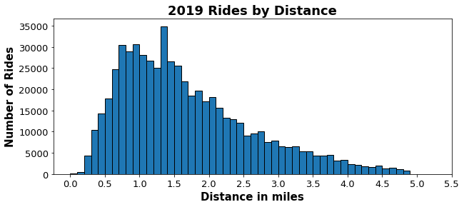

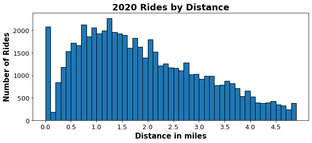

```python
#year 2019
plt.figure(figsize=(10,4))

plt.hist(data = df_19, x='distance_miles',bins=np.arange(0,5,0.1))

plt.xlabel('Distance in miles', fontsize=15, weight='bold')
plt.ylabel('Number of Rides', fontsize=15, weight='bold')
plt.xticks(np.arange(0, 6, 0.5), fontsize=13)
plt.yticks(fontsize=13)
plt.title('2019 Rides by Distance', fontsize=18, weight='bold');

#year 2020
plt.figure(figsize=(10,4))

plt.hist(data = df_20, x='distance_miles',bins=np.arange(0,5,0.1))

plt.xlabel('Distance in miles', fontsize=15, weight='bold')
plt.ylabel('Number of Rides', fontsize=15, weight='bold')
plt.xticks(np.arange(0, 5, 0.5), fontsize=13)
plt.yticks(fontsize=13)
plt.title('2020 Rides by Distance', fontsize=18, weight='bold');
```

## Peak hours of rides in 2019 and 2020

- In 2019, most of the bikes were used either in morning hours i.e. between 7 to 9 am or in evening hours i.e. 4 to 6 pm i.e. Bikes were mostly engaged during peak office hours.
- In 2020, we noticed that bike use frequency increases from 5 am onwards till 5 pm and then starts decreasing.

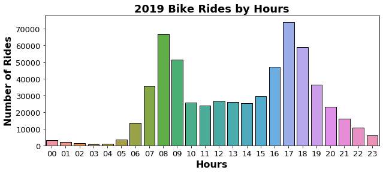

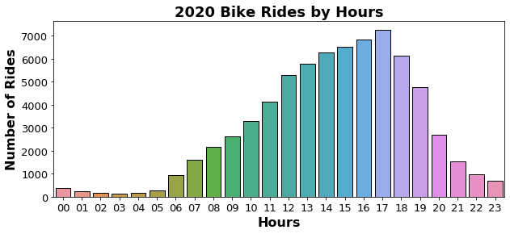

```python
plt.figure(figsize=(10,4))

ax = plt.subplot(111)

ax = sb.countplot(data=df_19, x='start_hour', ax=ax)

plt.ylabel('Number of Rides', fontsize=16, weight='bold')
plt.xlabel('Hours', fontsize=16, weight='bold')
plt.xticks(fontsize=13)
plt.yticks(fontsize=13)
plt.title('2019 Bike Rides by Hours', fontsize=18, weight='bold');


plt.figure(figsize=(10,4))

ax = plt.subplot(111)

ax = sb.countplot(data=df_20, x='start_hour', ax=ax)

plt.ylabel('Number of Rides', fontsize=16, weight='bold')
plt.xlabel('Hours', fontsize=16, weight='bold')
plt.xticks(fontsize=13)
plt.yticks(fontsize=13)
plt.title('2020 Bike Rides by Hours', fontsize=18, weight='bold');
```

## Rides by days of week for each user type in 2019 and 2020

- In 2019, we noticed a considerable difference in the number of subscribers vs customers while in 2020 the difference was quite less between members and casuals
- It can be noted from above visualisation that in 2019, more number of rides were taken on weekdays than on weekends while in 2020 maximum rides were taken on weekends.
- Also, in 2019, more subscribers used BayWheels service as compared to Customers but in 2020, maximum number of rides were taken by Customers(renamed as Casuals) and not subscribers

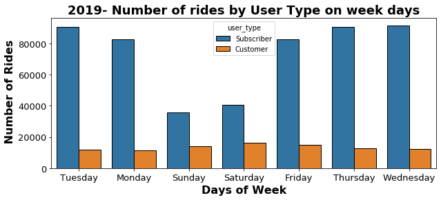

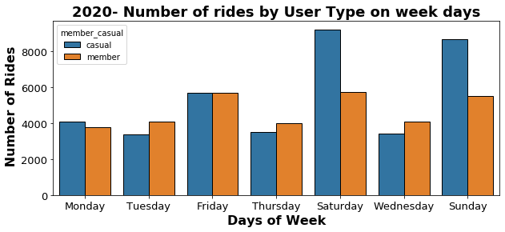

```python
plt.figure(figsize = (10,4))
sb.countplot(data = df_19 , x = 'start_day' , hue = 'user_type')
plt.ylabel(' Number of Rides', fontsize=16, weight='bold')
plt.xlabel('Days of Week', fontsize=16, weight='bold')
plt.xticks(fontsize=13)
plt.yticks(fontsize=13)
plt.title('2019- Number of rides by User Type on week days', fontsize=18, weight='bold');


plt.figure(figsize = (10,4))
sb.countplot(data = df_20 , x = 'start_day' , hue = 'member_casual')
plt.ylabel(' Number of Rides', fontsize=16, weight='bold')
plt.xlabel('Days of Week', fontsize=16, weight='bold')
plt.xticks(fontsize=13)
plt.yticks(fontsize=13)
plt.title('2020- Number of rides by User Type on week days', fontsize=18, weight='bold');
```

## Comparsion of User Type by days of week and duration in 2019 and 2020

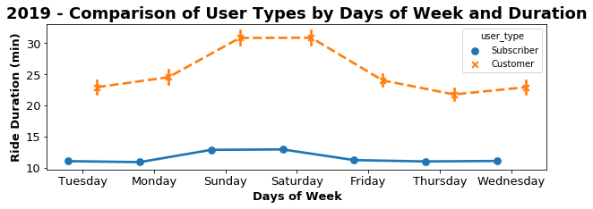

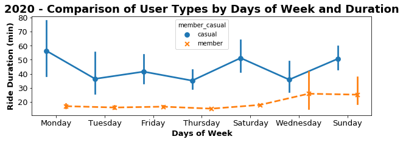

```python
df_19['interval'] = df_19['end_time'] - df_19['start_time']
df_19['duration'] = df_19['interval'] / pd.Timedelta(minutes=1)

df_20['interval'] = df_20['ended_at'] - df_20['started_at']
df_20['duration'] = df_20['interval'] / pd.Timedelta(minutes=1)

#user type vs duration vs day of week
plt.figure(figsize=([10,3]))
sb.pointplot(data=df_19, x='start_day', y='duration', hue='user_type', markers=["o","x"],linestyles=["-", "--"], dodge=0.4)
plt.xlabel('Days of Week',fontsize=13, weight='bold')
plt.ylabel('Ride Duration (min)',fontsize=13, weight='bold')
plt.xticks(fontsize=13)
plt.yticks(fontsize=13)
plt.title('2019 - Comparison of User Types by Days of Week and Duration', fontsize=18, weight='bold');


plt.figure(figsize=([10,3]))
sb.pointplot(data=df_20, x='start_day', y='duration', hue='member_casual', markers=["o","x"],linestyles=["-", "--"], dodge=0.4)
plt.xlabel('Days of Week',fontsize=13, weight='bold')
plt.ylabel('Ride Duration (min)',fontsize=13, weight='bold')
plt.xticks(fontsize=13)
plt.yticks(fontsize=13)
plt.title('2020 - Comparison of User Types by Days of Week and Duration', fontsize=18, weight='bold');
```

## Comparsion of User Type by Days of Week and Distance travelled in 2019 and 2020

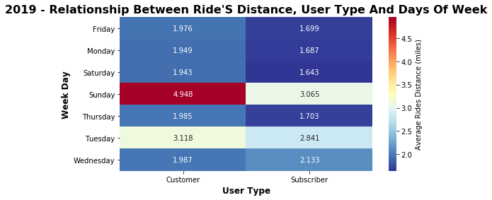

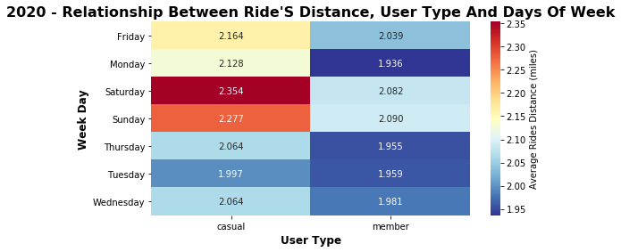

```python
#2019 days of week vs user type vs distance

plt.figure(figsize=[8, 4])
ride_means = df_19.groupby(['user_type','start_day']).mean()['distance_miles']
ride_means = ride_means.reset_index(name = 'distance_avg')
ride_means = ride_means.pivot(index = 'start_day', columns = 'user_type', values = 'distance_avg')

sb.heatmap(ride_means, annot = True, fmt = '.3f',
           cbar_kws = {'label':'Average Rides Distance (miles)'}, cmap = 'RdYlBu_r')
# Add title and format it
plt.title("2019 - Relationship between ride's distance, user type and days of week".title(),
               fontsize = 16, weight = "bold")
# Add x label and format it
plt.xlabel('User Type'.title(),
               fontsize = 12, weight = "bold")
# Add y label and format it
plt.ylabel('Week Day'.title(),
               fontsize = 12, weight = "bold");


#2020 days of week vs user type vs distance

plt.figure(figsize=[8, 4])
ride_means = df_20.groupby(['member_casual','start_day']).mean()['distance_miles']
ride_means = ride_means.reset_index(name = 'distance_avg')
ride_means = ride_means.pivot(index = 'start_day', columns = 'member_casual', values = 'distance_avg')

sb.heatmap(ride_means, annot = True, fmt = '.3f',
           cbar_kws = {'label':'Average Rides Distance (miles)'}, cmap = 'RdYlBu_r')
# Add title and format it
plt.title("2020 - Relationship between ride's distance, user type and days of week".title(),
               fontsize = 16, weight = "bold")
# Add x label and format it
plt.xlabel('User Type'.title(),
               fontsize = 12, weight = "bold")
# Add y label and format it
plt.ylabel('Week Day'.title(),
               fontsize = 12, weight = "bold");
```